# ESM 204 HW4

Tommy King, Charlie Wilson, Sarah Lam

5/23/2022

# 1 **Question 1: Damage Equation**

## 1.1 *Figure 1: Damages Resulting from Climate Change*

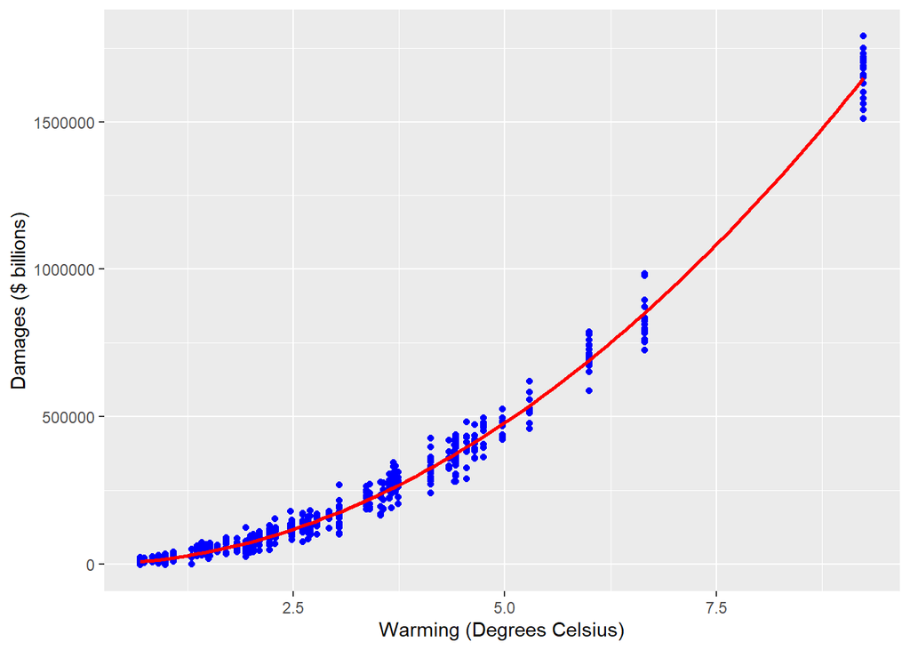

**Figure 1 Analysis:** Increasing temperatures will result in increased rates of damages, amounting to millions of billions of dollars over the next hundred years.

# 2 **Question 2: Predicted Damages**

## 2.1 *Figure 2: Damages over Time with and Without Pulse*

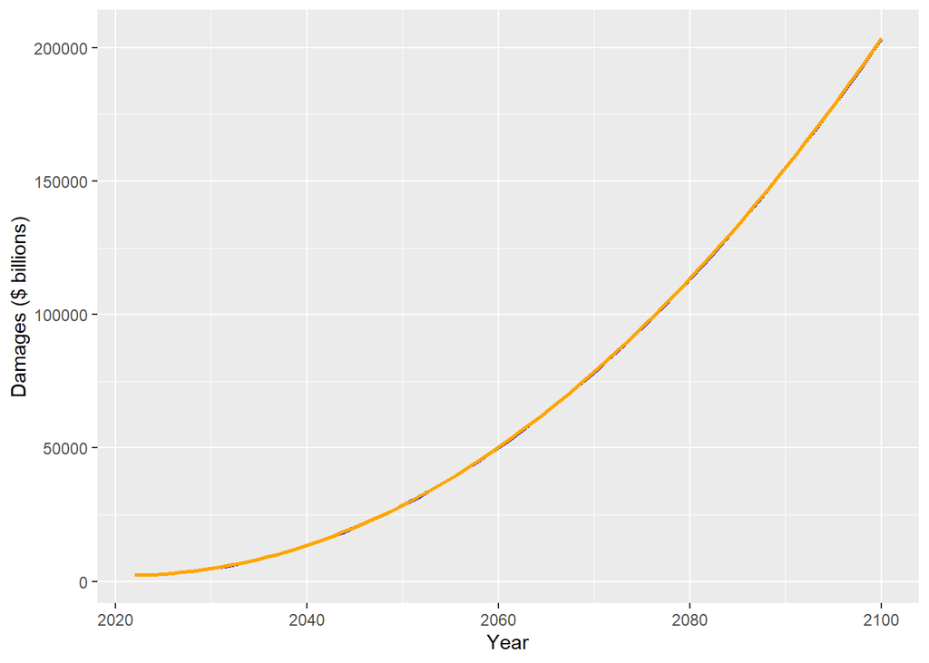

**Figure 2 Analysis:** Difference between pulse and no pulse scenario appears to be trivial, as denoted by orange and blue lines.

## 2.2 *Figures 3a/b: Absolute vs. Per Ton Damages Over Time*

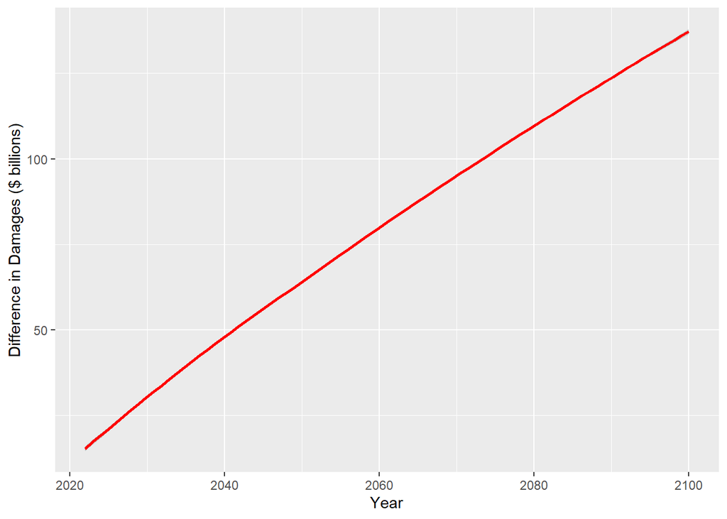

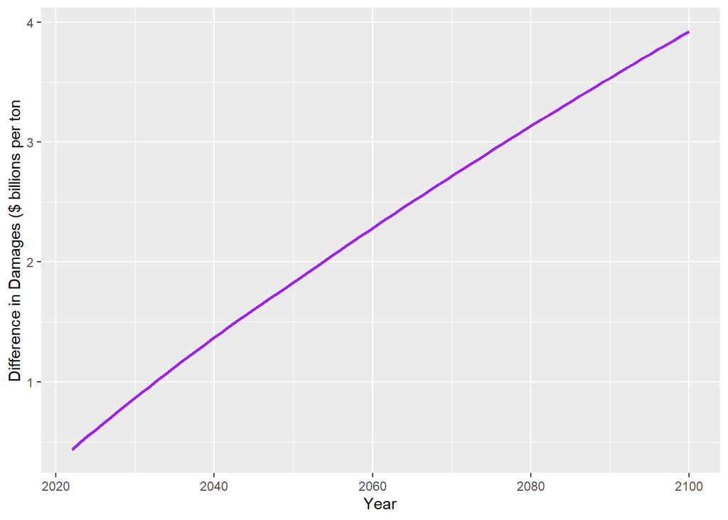

# 3 **Question 3: SCC Analysis**

## 3.1 *Figure 4: SCC Analysis with Various Discount Rates*

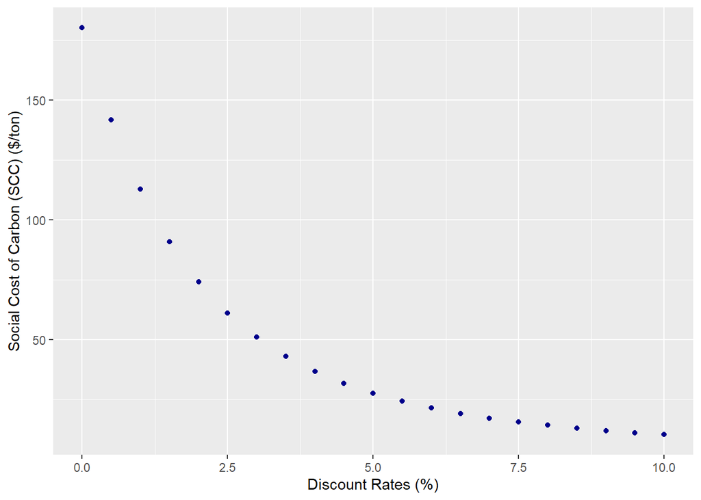

**Figure 4 Analysis**: Artificially increasing the discount rate lowers the SCC exponentially. Thus, the proposed rates by the Obama Administration and NY state lead to SCC values between $50 and 100.

# 4 **Question 4: Ramsey Rule**

## 4.1 *Figure 5: Ramsey Rule SCC evaluation*

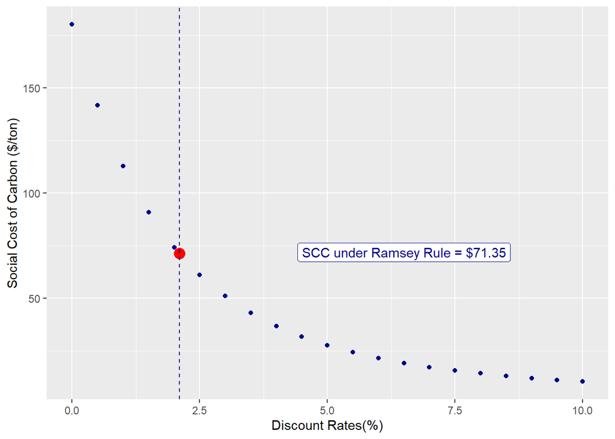

**Figure 5 Analysis:** NPV of future damages between current day and 2100 discounted at various levels with different discount rates (0-10% in increments of 0.5%). The red point shows the discount rate and accompanying SCC under the Ramsey Rule.

The SCC at the proposed discount rate under Ramsey Rule is $71.35/ton.

# 5 **Question 5: Comparing Policy Considerations**

Question 5 asks to consider business as usual policy (Policy A) compared to strong action against climate change (Policy B) in which:

*Policy A:* Either warming will occur as in the “baseline” (i.e. “no-pulse”) dataset above (this happens with probability 0.5) or warming each year will be 1.5 times that in the “baseline” dataset (with probability 0.5).

*Policy B:* Warming will continue until 2050 as in the “baseline” dataset, and then will stabilize at 1.29 degrees and stay that way forever.

## 5.1 *Figure 6: Policy A or B*

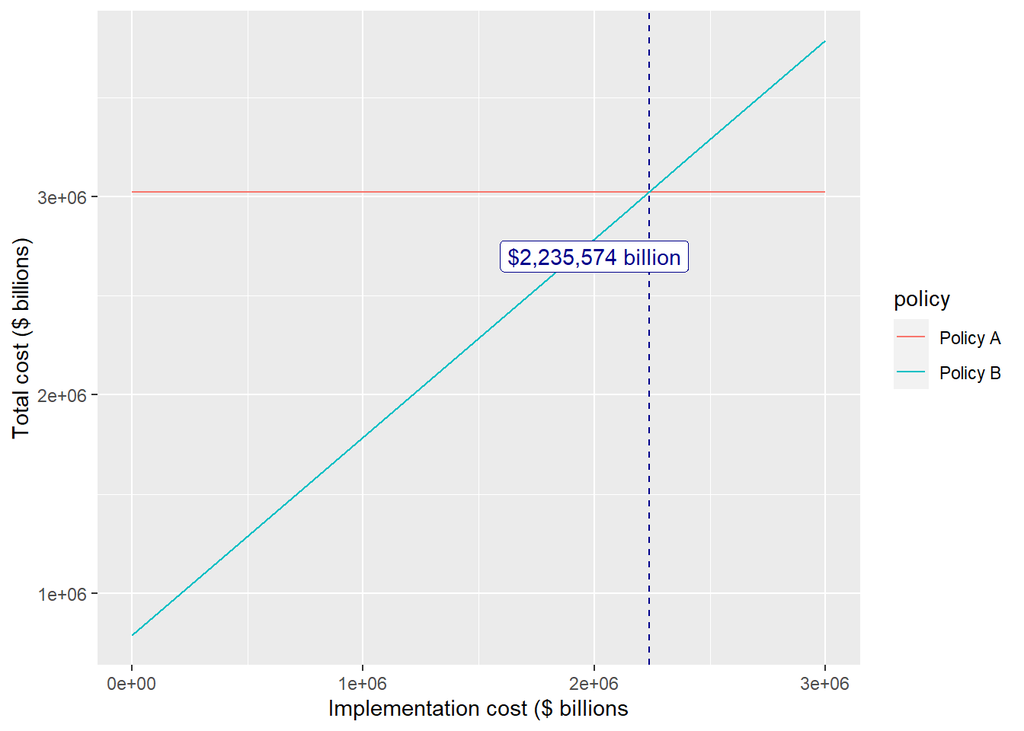

# 6 **Question 6: Risk Averse Advice**

Policy B is far better for society if society is more risk averse. This is because the costs of Policy B are known, whereas the costs of Policy A are unknown, making it far more risky. As such, Congress would select Policy B in most scenarios, as they can accurately understand the costs associated with Policy B.

In Policy A, there is a 50/50 chance that warming will follow the baseline under low costs or that warming will jump up 1.5x and increase costs immensely. So, society will be preferential to Policy B and that will likely be the choice that Congress takes for its people.